# Reproducible Research: Peer Assessment 1

## Load Libraries

```r
library(data.table)
library(dplyr)
library(lubridate)
```

```r
library(ggplot2)
library(datasets)
library(xtable)
```

## Loading and preprocessing the data

```r
knitr::opts_chunk$set(fig.width=12, fig.height=8, fig.path='', echo = TRUE,
                     fig.keep = "all", results = "asis")

## Read activity.csv, set column classes, and format as tbl_df
actyData <- read.csv("activity.csv", header = TRUE, colClasses = c("integer", "Date",
                                                                "integer"))
actyData <- tbl_df(actyData)

## Center Justify All Plot Titles for ggplot
theme_update(plot.title = element_text(hjust = 0.5))
```

## What is mean total number of steps taken per day?

For this part of the assignment, you can ignore the missing values in the dataset.  
1. Make a histogram of the total number of steps taken each day.  
2. Calculate and report the mean and median total number of steps taken per day.

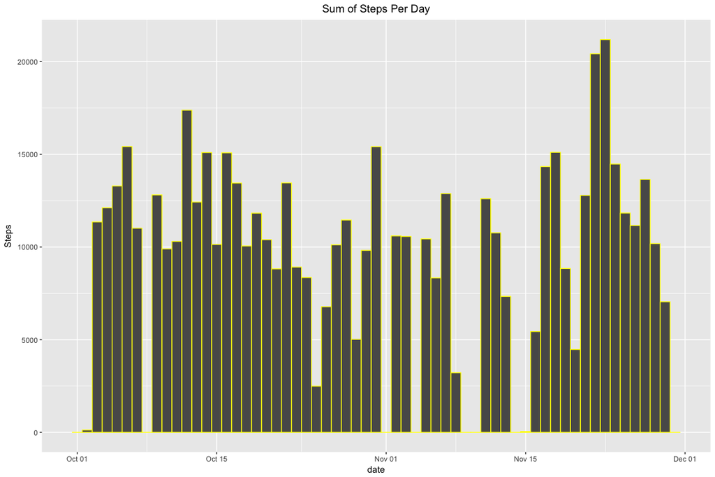

```r
## Summarize actyData by the number of steps per day
stepsPerDay <- actyData %>% group_by(date) %>% summarise(dailySteps = sum(steps))

## 1. Create histogram of steps per day:
## (using the number of daily steps as the total weight)
g <- ggplot(stepsPerDay, aes(date, weight = dailySteps))
g + geom_histogram(binwidth = 1, color="yellow") +
        labs(title = "Sum of Steps Per Day", y = "Steps")
```

```r
        ## binwidth is each day


summaryData <- actyData %>% group_by(date) %>% summarise(meanSteps = mean(steps,
        na.rm=TRUE),medianSteps = median(steps, na.rm=TRUE))

##2. Calculate and report the mean and median total number of steps taken per day:
xtableSummaryData <- mutate(summaryData, date = as.character(date))
xt <- xtable(xtableSummaryData)
print(xt, type = "html")
```

|  | date | meanSteps | medianSteps |
| --- | --- | --- | --- |
| 1 | 2012-10-01 |  |  |
| 2 | 2012-10-02 | 0.44 | 0.00 |
| 3 | 2012-10-03 | 39.42 | 0.00 |
| 4 | 2012-10-04 | 42.07 | 0.00 |
| 5 | 2012-10-05 | 46.16 | 0.00 |
| 6 | 2012-10-06 | 53.54 | 0.00 |
| 7 | 2012-10-07 | 38.25 | 0.00 |
| 8 | 2012-10-08 |  |  |
| 9 | 2012-10-09 | 44.48 | 0.00 |
| 10 | 2012-10-10 | 34.38 | 0.00 |
| 11 | 2012-10-11 | 35.78 | 0.00 |
| 12 | 2012-10-12 | 60.35 | 0.00 |
| 13 | 2012-10-13 | 43.15 | 0.00 |
| 14 | 2012-10-14 | 52.42 | 0.00 |
| 15 | 2012-10-15 | 35.20 | 0.00 |
| 16 | 2012-10-16 | 52.38 | 0.00 |
| 17 | 2012-10-17 | 46.71 | 0.00 |
| 18 | 2012-10-18 | 34.92 | 0.00 |
| 19 | 2012-10-19 | 41.07 | 0.00 |
| 20 | 2012-10-20 | 36.09 | 0.00 |
| 21 | 2012-10-21 | 30.63 | 0.00 |
| 22 | 2012-10-22 | 46.74 | 0.00 |
| 23 | 2012-10-23 | 30.97 | 0.00 |
| 24 | 2012-10-24 | 29.01 | 0.00 |
| 25 | 2012-10-25 | 8.65 | 0.00 |
| 26 | 2012-10-26 | 23.53 | 0.00 |
| 27 | 2012-10-27 | 35.14 | 0.00 |
| 28 | 2012-10-28 | 39.78 | 0.00 |
| 29 | 2012-10-29 | 17.42 | 0.00 |
| 30 | 2012-10-30 | 34.09 | 0.00 |
| 31 | 2012-10-31 | 53.52 | 0.00 |
| 32 | 2012-11-01 |  |  |
| 33 | 2012-11-02 | 36.81 | 0.00 |
| 34 | 2012-11-03 | 36.70 | 0.00 |
| 35 | 2012-11-04 |  |  |
| 36 | 2012-11-05 | 36.25 | 0.00 |
| 37 | 2012-11-06 | 28.94 | 0.00 |
| 38 | 2012-11-07 | 44.73 | 0.00 |
| 39 | 2012-11-08 | 11.18 | 0.00 |
| 40 | 2012-11-09 |  |  |
| 41 | 2012-11-10 |  |  |
| 42 | 2012-11-11 | 43.78 | 0.00 |
| 43 | 2012-11-12 | 37.38 | 0.00 |
| 44 | 2012-11-13 | 25.47 | 0.00 |
| 45 | 2012-11-14 |  |  |
| 46 | 2012-11-15 | 0.14 | 0.00 |
| 47 | 2012-11-16 | 18.89 | 0.00 |
| 48 | 2012-11-17 | 49.79 | 0.00 |
| 49 | 2012-11-18 | 52.47 | 0.00 |
| 50 | 2012-11-19 | 30.70 | 0.00 |
| 51 | 2012-11-20 | 15.53 | 0.00 |
| 52 | 2012-11-21 | 44.40 | 0.00 |
| 53 | 2012-11-22 | 70.93 | 0.00 |
| 54 | 2012-11-23 | 73.59 | 0.00 |
| 55 | 2012-11-24 | 50.27 | 0.00 |
| 56 | 2012-11-25 | 41.09 | 0.00 |
| 57 | 2012-11-26 | 38.76 | 0.00 |
| 58 | 2012-11-27 | 47.38 | 0.00 |
| 59 | 2012-11-28 | 35.36 | 0.00 |
| 60 | 2012-11-29 | 24.47 | 0.00 |
| 61 | 2012-11-30 |  |  |

## What is the average daily activity pattern?

1. Make a time series plot (i.e. type = “l”) of the 5-minute interval (x-axis) and the average number of steps taken, averaged across all days (y-axis)
2. Which 5-minute interval, on average across all the days in the dataset, contains the maximum number of steps?

[figure not shown]

```r
## Group data by activity interval and then summarize by mean number of steps taken
intervalData <- actyData %>% group_by(interval) %>% summarise(meanSteps = mean(steps,
        na.rm=TRUE))

## 1. Make a time series plot -- intervals on X-axis and mean steps on the Y-axis
h <- qplot(x =interval, y =meanSteps, data=intervalData, geom = "line")
h + labs(title = "Average Steps Per Interval", x = "5 Second Interval", y =
                 "Averge Number of Steps")
```

```r
## Arrange intervals by highest to lowest periods of meanSteps
mostActive <- arrange(intervalData, desc(meanSteps))

## 2. Most active 5-min interval on average across all days
## Interval 835 is most active:
xt <- xtable(mostActive[1,])
print(xt, type = "html")
```

|  | interval | meanSteps |
| --- | --- | --- |
| 1 | 835 | 206.17 |

## Imputing missing values

Note that there are a number of days/intervals where there are missing values (coded as NA). The presence of missing days may introduce bias into some calculations or summaries of the data.

1. Calculate and report the total number of missing values in the dataset (i.e. the total number of rows with NAs)
2. Devise a strategy for filling in all of the missing values in the dataset. The strategy does not need to be sophisticated. For example, you could use the mean/median for that day, or the mean for that 5-minute interval, etc.
3. Create a new dataset that is equal to the original dataset but with the missing data filled in.
4. Make a histogram of the total number of steps taken each day and Calculate and report the mean and median total number of steps taken per day. Do these values differ from the estimates from the first part of the assignment? What is the impact of imputing missing data on the estimates of the total daily number of steps?

```r
## 1: Calculate and report how many rows have NAs:
## Where Steps = TRUE -- 2304 NAs
rowsNA <- is.na(actyData)
rowsNA <- data.frame(rowsNA)
xt <-xtable(summary(rowsNA))
print(xt, type = "html")
```

[output not shown]

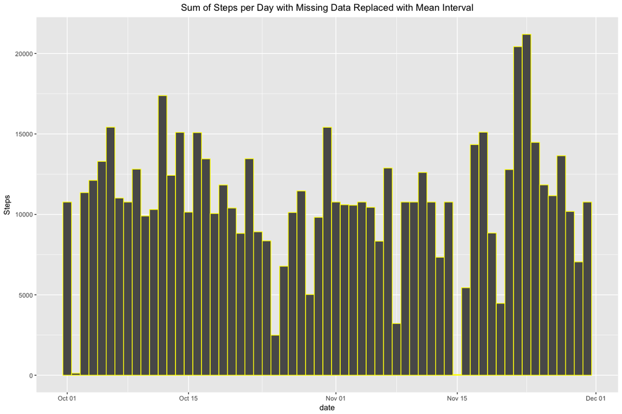

```r
## 2: Strategy: replace NAs with Interval Mean

## Create logical vector on rows of steps with NAs
naVector <- as.vector(rowsNA[,1])

## Repeat the interval means across all 61 days
intervalMeans <- rep(intervalData$meanSteps, 61)

## Create new table and add the NA logical vector and interval means together with data
modActyData <- actyData %>% mutate(NAvect = naVector, intervalMeans)

## Temporarily set all steps NAs to 0 to enable next step to insert the intervalMeans:
modActyData[is.na(modActyData)] <- 0   ## All Table NAs set to 0

## 3: Create new dataset with missing data filled in:
## Multiply the NA logical column by the interval means and add previous value of steps
modActyData <- modActyData %>% mutate(steps = steps+(NAvect*intervalMeans))

## 4(a):Make a histogram of the total number of steps taken each day and Calculate
## and 4(b): report the mean and median total number of steps taken per day.

## First, summarize new data set by the number of steps per day for histogram:
newStepsPerDay <- modActyData %>% group_by(date) %>% summarise(dailySteps = sum(steps))

## 4(a). Create histogram of steps per day using the number of daily steps as the total weight
t <- ggplot(newStepsPerDay, aes(date, weight = dailySteps))
t + geom_histogram(binwidth = 1, color="yellow") +
        labs(title = "Sum of Steps per Day with Missing Data Replaced with Mean Interval",
             y = "Steps")
```

```r
                ## binwidth is each day

## Compare new and previous summaries :
newSummaryData <- modActyData %>% group_by(date) %>% summarise(new.Mean.Steps =
        mean(steps, na.rm=TRUE),new.Median.Steps = median(steps, na.rm=TRUE))

## 4(b). Report the New mean and median total number of steps per day
xtableNewSummaryData <- mutate(newSummaryData, date = as.character(date))
xt <- xtable(xtableNewSummaryData)
print(xt, type = "html")
```

|  | date | new.Mean.Steps | new.Median.Steps |
| --- | --- | --- | --- |
| 1 | 2012-10-01 | 37.38 | 34.11 |
| 2 | 2012-10-02 | 0.44 | 0.00 |
| 3 | 2012-10-03 | 39.42 | 0.00 |
| 4 | 2012-10-04 | 42.07 | 0.00 |
| 5 | 2012-10-05 | 46.16 | 0.00 |
| 6 | 2012-10-06 | 53.54 | 0.00 |
| 7 | 2012-10-07 | 38.25 | 0.00 |
| 8 | 2012-10-08 | 37.38 | 34.11 |
| 9 | 2012-10-09 | 44.48 | 0.00 |
| 10 | 2012-10-10 | 34.38 | 0.00 |
| 11 | 2012-10-11 | 35.78 | 0.00 |
| 12 | 2012-10-12 | 60.35 | 0.00 |
| 13 | 2012-10-13 | 43.15 | 0.00 |
| 14 | 2012-10-14 | 52.42 | 0.00 |
| 15 | 2012-10-15 | 35.20 | 0.00 |
| 16 | 2012-10-16 | 52.38 | 0.00 |
| 17 | 2012-10-17 | 46.71 | 0.00 |
| 18 | 2012-10-18 | 34.92 | 0.00 |
| 19 | 2012-10-19 | 41.07 | 0.00 |
| 20 | 2012-10-20 | 36.09 | 0.00 |
| 21 | 2012-10-21 | 30.63 | 0.00 |
| 22 | 2012-10-22 | 46.74 | 0.00 |
| 23 | 2012-10-23 | 30.97 | 0.00 |
| 24 | 2012-10-24 | 29.01 | 0.00 |
| 25 | 2012-10-25 | 8.65 | 0.00 |
| 26 | 2012-10-26 | 23.53 | 0.00 |
| 27 | 2012-10-27 | 35.14 | 0.00 |
| 28 | 2012-10-28 | 39.78 | 0.00 |
| 29 | 2012-10-29 | 17.42 | 0.00 |
| 30 | 2012-10-30 | 34.09 | 0.00 |
| 31 | 2012-10-31 | 53.52 | 0.00 |
| 32 | 2012-11-01 | 37.38 | 34.11 |
| 33 | 2012-11-02 | 36.81 | 0.00 |
| 34 | 2012-11-03 | 36.70 | 0.00 |
| 35 | 2012-11-04 | 37.38 | 34.11 |
| 36 | 2012-11-05 | 36.25 | 0.00 |
| 37 | 2012-11-06 | 28.94 | 0.00 |
| 38 | 2012-11-07 | 44.73 | 0.00 |
| 39 | 2012-11-08 | 11.18 | 0.00 |
| 40 | 2012-11-09 | 37.38 | 34.11 |
| 41 | 2012-11-10 | 37.38 | 34.11 |
| 42 | 2012-11-11 | 43.78 | 0.00 |
| 43 | 2012-11-12 | 37.38 | 0.00 |
| 44 | 2012-11-13 | 25.47 | 0.00 |
| 45 | 2012-11-14 | 37.38 | 34.11 |
| 46 | 2012-11-15 | 0.14 | 0.00 |
| 47 | 2012-11-16 | 18.89 | 0.00 |
| 48 | 2012-11-17 | 49.79 | 0.00 |
| 49 | 2012-11-18 | 52.47 | 0.00 |
| 50 | 2012-11-19 | 30.70 | 0.00 |
| 51 | 2012-11-20 | 15.53 | 0.00 |
| 52 | 2012-11-21 | 44.40 | 0.00 |
| 53 | 2012-11-22 | 70.93 | 0.00 |
| 54 | 2012-11-23 | 73.59 | 0.00 |
| 55 | 2012-11-24 | 50.27 | 0.00 |
| 56 | 2012-11-25 | 41.09 | 0.00 |
| 57 | 2012-11-26 | 38.76 | 0.00 |
| 58 | 2012-11-27 | 47.38 | 0.00 |
| 59 | 2012-11-28 | 35.36 | 0.00 |
| 60 | 2012-11-29 | 24.47 | 0.00 |
| 61 | 2012-11-30 | 37.38 | 34.11 |

```r
## 4(c). Do these values differ from the estimates from the first part of the assignment?
compareData <- cbind(summaryData, select(newSummaryData, new.Mean.Steps, new.Median.Steps))
compareData <- select(compareData,date, meanSteps, new.Mean.Steps, medianSteps,
                      new.Median.Steps)

## 4(d): What is the impact of imputing missing data on the estimates of the total
## daily number of steps?
## Print old and new side-by-side
## Difference in means which were previously NaN now have a value
## Difference in median which now has a value where it was NA previously
## and missing days now filled-in on the histograms above
xtableCompareData <- mutate(compareData, date = as.character(date))
xt <- xtable(xtableCompareData)
print(xt, type = "html")
```

|  | date | meanSteps | new.Mean.Steps | medianSteps | new.Median.Steps |
| --- | --- | --- | --- | --- | --- |
| 1 | 2012-10-01 |  | 37.38 |  | 34.11 |
| 2 | 2012-10-02 | 0.44 | 0.44 | 0.00 | 0.00 |
| 3 | 2012-10-03 | 39.42 | 39.42 | 0.00 | 0.00 |
| 4 | 2012-10-04 | 42.07 | 42.07 | 0.00 | 0.00 |
| 5 | 2012-10-05 | 46.16 | 46.16 | 0.00 | 0.00 |
| 6 | 2012-10-06 | 53.54 | 53.54 | 0.00 | 0.00 |
| 7 | 2012-10-07 | 38.25 | 38.25 | 0.00 | 0.00 |
| 8 | 2012-10-08 |  | 37.38 |  | 34.11 |
| 9 | 2012-10-09 | 44.48 | 44.48 | 0.00 | 0.00 |
| 10 | 2012-10-10 | 34.38 | 34.38 | 0.00 | 0.00 |
| 11 | 2012-10-11 | 35.78 | 35.78 | 0.00 | 0.00 |
| 12 | 2012-10-12 | 60.35 | 60.35 | 0.00 | 0.00 |
| 13 | 2012-10-13 | 43.15 | 43.15 | 0.00 | 0.00 |
| 14 | 2012-10-14 | 52.42 | 52.42 | 0.00 | 0.00 |
| 15 | 2012-10-15 | 35.20 | 35.20 | 0.00 | 0.00 |
| 16 | 2012-10-16 | 52.38 | 52.38 | 0.00 | 0.00 |
| 17 | 2012-10-17 | 46.71 | 46.71 | 0.00 | 0.00 |
| 18 | 2012-10-18 | 34.92 | 34.92 | 0.00 | 0.00 |
| 19 | 2012-10-19 | 41.07 | 41.07 | 0.00 | 0.00 |
| 20 | 2012-10-20 | 36.09 | 36.09 | 0.00 | 0.00 |
| 21 | 2012-10-21 | 30.63 | 30.63 | 0.00 | 0.00 |
| 22 | 2012-10-22 | 46.74 | 46.74 | 0.00 | 0.00 |
| 23 | 2012-10-23 | 30.97 | 30.97 | 0.00 | 0.00 |
| 24 | 2012-10-24 | 29.01 | 29.01 | 0.00 | 0.00 |
| 25 | 2012-10-25 | 8.65 | 8.65 | 0.00 | 0.00 |
| 26 | 2012-10-26 | 23.53 | 23.53 | 0.00 | 0.00 |
| 27 | 2012-10-27 | 35.14 | 35.14 | 0.00 | 0.00 |
| 28 | 2012-10-28 | 39.78 | 39.78 | 0.00 | 0.00 |
| 29 | 2012-10-29 | 17.42 | 17.42 | 0.00 | 0.00 |
| 30 | 2012-10-30 | 34.09 | 34.09 | 0.00 | 0.00 |
| 31 | 2012-10-31 | 53.52 | 53.52 | 0.00 | 0.00 |
| 32 | 2012-11-01 |  | 37.38 |  | 34.11 |
| 33 | 2012-11-02 | 36.81 | 36.81 | 0.00 | 0.00 |
| 34 | 2012-11-03 | 36.70 | 36.70 | 0.00 | 0.00 |
| 35 | 2012-11-04 |  | 37.38 |  | 34.11 |
| 36 | 2012-11-05 | 36.25 | 36.25 | 0.00 | 0.00 |
| 37 | 2012-11-06 | 28.94 | 28.94 | 0.00 | 0.00 |
| 38 | 2012-11-07 | 44.73 | 44.73 | 0.00 | 0.00 |
| 39 | 2012-11-08 | 11.18 | 11.18 | 0.00 | 0.00 |
| 40 | 2012-11-09 |  | 37.38 |  | 34.11 |
| 41 | 2012-11-10 |  | 37.38 |  | 34.11 |
| 42 | 2012-11-11 | 43.78 | 43.78 | 0.00 | 0.00 |
| 43 | 2012-11-12 | 37.38 | 37.38 | 0.00 | 0.00 |
| 44 | 2012-11-13 | 25.47 | 25.47 | 0.00 | 0.00 |
| 45 | 2012-11-14 |  | 37.38 |  | 34.11 |
| 46 | 2012-11-15 | 0.14 | 0.14 | 0.00 | 0.00 |
| 47 | 2012-11-16 | 18.89 | 18.89 | 0.00 | 0.00 |
| 48 | 2012-11-17 | 49.79 | 49.79 | 0.00 | 0.00 |
| 49 | 2012-11-18 | 52.47 | 52.47 | 0.00 | 0.00 |
| 50 | 2012-11-19 | 30.70 | 30.70 | 0.00 | 0.00 |
| 51 | 2012-11-20 | 15.53 | 15.53 | 0.00 | 0.00 |
| 52 | 2012-11-21 | 44.40 | 44.40 | 0.00 | 0.00 |
| 53 | 2012-11-22 | 70.93 | 70.93 | 0.00 | 0.00 |
| 54 | 2012-11-23 | 73.59 | 73.59 | 0.00 | 0.00 |
| 55 | 2012-11-24 | 50.27 | 50.27 | 0.00 | 0.00 |
| 56 | 2012-11-25 | 41.09 | 41.09 | 0.00 | 0.00 |
| 57 | 2012-11-26 | 38.76 | 38.76 | 0.00 | 0.00 |
| 58 | 2012-11-27 | 47.38 | 47.38 | 0.00 | 0.00 |
| 59 | 2012-11-28 | 35.36 | 35.36 | 0.00 | 0.00 |
| 60 | 2012-11-29 | 24.47 | 24.47 | 0.00 | 0.00 |
| 61 | 2012-11-30 |  | 37.38 |  | 34.11 |

```r
## Compare mean & median from old and new summaries AND with orignal data set:
##
noChangeMeans <- c(mean(summaryData$meanSteps, na.rm =TRUE),
                mean(newSummaryData$new.Mean.Steps, na.rm =TRUE),
                mean(actyData$steps, na.rm = TRUE))

noChangeMedians <- c(median(summaryData$medianSteps, na.rm =TRUE),
                median(newSummaryData$new.Median.Steps, na.rm =TRUE),
                median(actyData$steps, na.rm=TRUE))

noChanges <- matrix(data = c(noChangeMeans,noChangeMedians),nrow = 3, ncol = 2,
                    byrow = FALSE)
noChanges <- data.frame(noChanges, row.names = c("1st Summary", "2nd Summary", "Orignial Data"))
noChanges <- tbl_df(noChanges)
noChanges <- rename(noChanges, mean = X1, median = X2)
xt <- xtable(noChanges)
## 4(d): What is the impact of imputing missing data
print(xt, type ="html")
```

|  | mean | median |
| --- | --- | --- |
| 1st Summary | 37.38 | 0.00 |
| 2nd Summary | 37.38 | 0.00 |
| Orignial Data | 37.38 | 0.00 |

## Are there differences in activity patterns between weekdays and weekends?

1. Create a new factor variable in the dataset with two levels – “weekday” and “weekend” indicating whether a given date is a weekday or weekend day.
2. Make a panel plot containing a time series plot (i.e. type = “l”) of the 5-minute interval (x-axis) and the average number of steps taken, averaged across all weekday days or weekend days (y-axis).

```r
## Compute day of week using wday(date) -- note different than weekdays() function
daysModActyData <- mutate(modActyData, dayOfWeek = wday(date))

## 1. Create a new factor of dayCat (Weekday/Weekend), and mutate data
daysModActyData <- mutate(daysModActyData, dayCatagory = factor(1* ((dayOfWeek == 1) |
        (dayOfWeek == 7)), labels = c("Weekday", "Weekend")))

## Mutate and Group data on Weekend/Weekday and summarize mean and median steps
daySummaryData <- daysModActyData %>% group_by(dayCatagory) %>% summarise(meanSteps =
        mean(steps, na.rm=TRUE),medianSteps = median(steps, na.rm=TRUE))

## 1. New Factor Vairable in the modified dataset
xt <- xtable(daySummaryData)
print(xt, type = "html")
```

|  | dayCatagory | meanSteps | medianSteps |
| --- | --- | --- | --- |
| 1 | Weekday | 35.61 | 0.00 |
| 2 | Weekend | 42.37 | 0.00 |

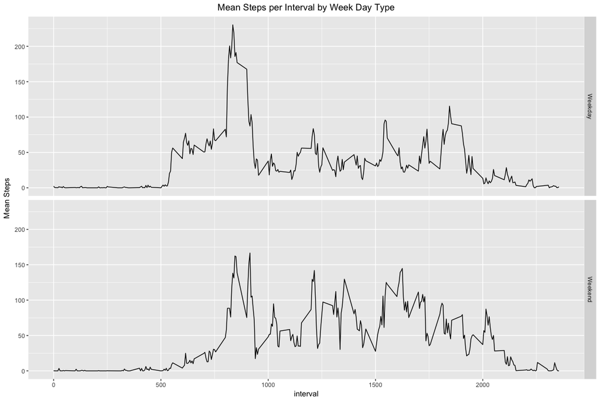

```r
## 1. New Factor Vairable and means group by interval and dayCatagory
daysIntervalData <- daysModActyData %>% group_by(interval, dayCatagory) %>%
        summarise(meanSteps = mean(steps, na.rm=TRUE))

## 2 Make a panel plot:
w <- qplot(interval, meanSteps, data = daysIntervalData, facets = dayCatagory ~.,
           geom = "line")
w + labs(title = "Mean Steps per Interval by Week Day Type", y = "Mean Steps")
```